# Visual illusions

Giorgio Ganis, Andy Wills

## Before you start…

Before starting this exercise, you should have completed **all** the relevant Absolute Beginers’, Part 1 workshop exercises. If not, take a look at those exercises before continuing. Each section below also indicates which of the earlier worksheets are relevant.

## Getting the data into R

**Relevant worksheet:** Intro to RStudio, Entering data by hand

In order to complete this worksheet, you’ll need to have downloaded your CSV file from the PsycEL exercise. **See the instructions on PsycEL for how to do this.**

Once you have downloaded your CSV file, open a project on RStudio Server for this analysis, create a script file, and upload your CSV to your project.

**Plymouth University students**: Create/open your project named `psyc413`; within that create a script file called `illusions.R`. Enter all comments and commands into that script and run them from there.

## Exploring your data

### Load

**Relevant worksheet:** Exploring incomes

Load the *tidyverse* package, and load your data.

```r
# Load tidyverse
library(tidyverse)
# Load data into 'ill'
ill <- read_csv("GG.csv")
```

**Note**: Everyone’s CSV file has a different name. For example, yours might be called `10435678 GG.csv`. In the example below, you’ll need to replace `GG.csv` with the name of your personal CSV file.

### Inspect

Look at the data by clicking on it in the *Environment* tab in RStudio. Each row is one trial; here’s what each of the columns contain:

[output not shown]

There may be an extra column called “Pattern”, but you can just ignore it. You completed 60 trials in total. Each angle was presented 10 times.

## Muller-Lyer illusion

**Relevant worksheet:** Exploring data, Group differences.

### Filter

To look at the Muller-Lyer illusion, you first need to filter the data, so that you just have the trials on which you did the Muller-Lyer illusion. We use the `filter` command to do this, as covered in the *Group Differences* worksheet:

```r
# Put data from Muller-Lyer illusion into 'mull'
mull <- ill %>% filter(Illusion == "M")
```

Your Muller-Lyer data are now in the data frame `mull`.

### Size of illusion, by angle

Did you experience the Muller-Lyer illusion? If so, did the angle of the lines affect the size of the illusion?

To look at this, you calculate the average(mean) size of your error in estimating the length of the line. You do this separately for each angle. If you did not experience the illusion, your average error would be around zero for all angles.

The error of your judgement on each trial is in the `Difference200` column of your `mull` data frame. The angle is in the `Angle` column. You can therefore calculate your mean error for each angle using the `group_by`, `summarize` and `mean` commands, as we covered in the *Group Differences* worksheet:

```r
# Group data by 'Angle', take mean of 'Difference200'
mull %>% group_by(Angle) %>% summarise(mean(Difference200))
```

```
# A tibble: 3 × 2
  Angle `mean(Difference200)`
  <dbl>                 <dbl>
1    45                  14
2    90                  -8.5
3   135                 -15.6
```

As before, you can safely ignore the “ungrouping” message that you receive.

In this example, the participant under-estimated line length with the “arrow heads” (Angle > 90), and over-estimated line length with the “arrow tails” ( Angle < 90). Your data may be different.

### Violin plot

In the above example, the mean size of the illusion varied by angle, but were your responses pretty much the same each time you saw a particular stimulus, or did they vary a lot? (Recall that you saw each stimulus at least ten times).

So, instead, we’re going to make a *violin plot*. A violin plot is just a density plot, rotated anticlockwise, and mirror copied to make a symmetrical, vase-like picture. For example, here’s a density plot of some data:

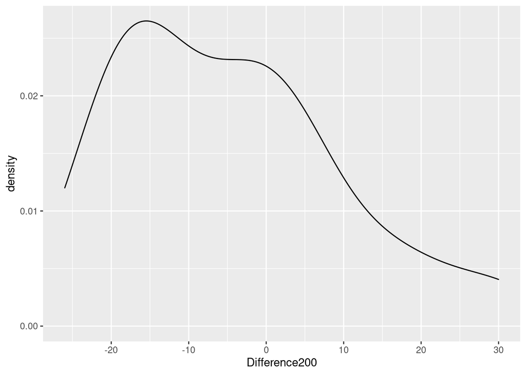

…and here’s the same data shown as a violin plot:

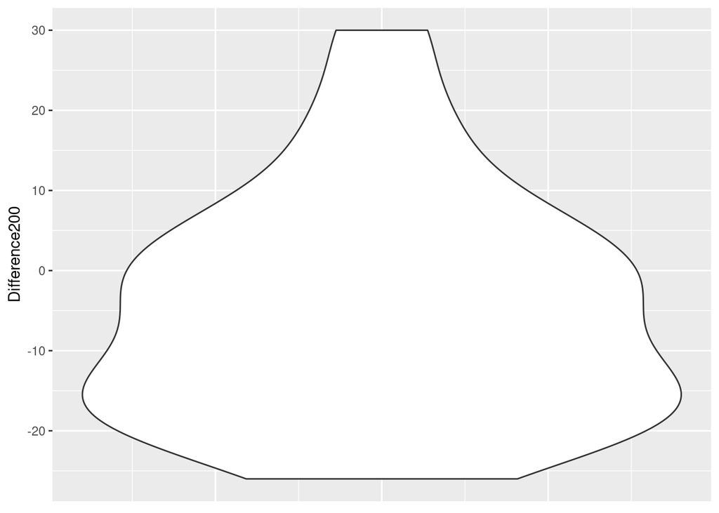

It’s called a violin plot because some people think it looks a bit like a violin. Can’t see it myself, but there you go…

The thing that makes a violin plot useful is that we can put a lot of them on the same graph, like this:

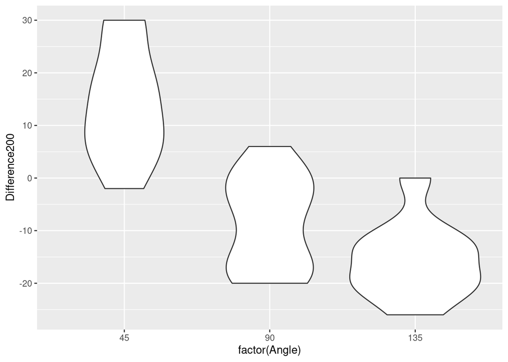

```r
# Produce violin plots for 'Difference200', for each value of 'Angle'
mull %>% ggplot(aes(x=factor(Angle), y=Difference200)) + geom_violin()
```

In this example, we can see that the range of lengths the participant produced in response to, for example, the 45 degree stimulus, barely overlaps with the range of lengths produced in response to the 135 degree stimulus. Your data may be different.

#### Explanation of command

`ggplot` is the command in R used to draw graphs

`aes` tells ggplot which columns of your data frame to use in the plot. In this case, we want ‘Angle’ on the x axis, and ‘Difference200’ (i.e. the size of the illusion) on the y axis.

`+ geom_violin()` says that the type of graph we want is a violin chart.

### Evidence

**Relevant worksheet:** Evidence

There’s quite a lot more that might be done with this data set, but you haven’t yet been taught the best techniques to do so (these will come in a later course). For now, we’re just going to compare the two stimuli most commonly used in a Muller-Lyer experiment - the 45 degree, and 135 degree stimuli. To do this, we make use of the `filter` command again, selecting just the 45 degree and 135 degree angles:

```r
# Select data from 45- and 135-degree conditions; place into 'mut'
mut <- mull %>% filter(Angle == 45 | Angle == 135)
```

As we’ve already seen (at least for our example data), the length of the line was over-estimated at 45 degrees, and under-estimated at 135 degrees (see the table of means, above). We also saw that the range of lengths estimated for 45 degrees barely overlapped with the range of lengths estimated for 135 degrees (see the violin plot, above).

How likely is it that this difference between the estimates at 45 degrees and 135 degrees is down to chance? As we saw in the *Evidence* worksheet, the best way to answer this question is to calculate a Bayes Factor. In this case, the data frame is `mut`, which we just made with the `filter` command above. The column `Difference200` contains the size of the illusion, and the column `Angle` contains the angle of the stimulus:

```r
# Load BayesFactor package
library(BayesFactor, quietly = TRUE)
# Perform Bayesian t-test on effect of 'Angle' on 'Difference200'
ttestBF(formula = Difference200 ~ Angle, data = data.frame(mut))
```

```
Bayes factor analysis
--------------
[1] Alt., r=0.707 : 9985.603 ±0%

Against denominator:
  Null, mu1-mu2 = 0
---
Bayes factor type: BFindepSample, JZS
```

In this example, the Bayes Factor is about 9986, so it’s almost 10,000 times as likely there is a difference, than there isn’t. This is good evidence for the presence of a Muller-Lyer illusion in this participant. How does it look for your data?

**Note**: If you’re looking back at this activity after having done the *Intermediate Guide to R*, you might be wondering why an *independent samples* test is being used here, when this appears to be a repeated-measures (“within-subject”) design. This is because the current experiment is a special case. Although the manipulation is within-subject, there is just one participant in total (you). In these single-participant designs, we typically treat each response as an independent sample of the underlying distribution from that single participant. When we have multiple responses from multiple participants, it gets more complicated, and we need to use repeated-measures designs.

## T illusion

Now do the following:

1. Produce a violin plot for the *other* illusion type in your data file, the T illusion. How does angle affect the size of the illusion in this case?
2. Export your violin plot, using the *Export* icon on RStudio’s *Plots* window, and selecting “Save as image…”. Give it a meaninful file name (e.g. “illusion-violin”) and click ‘Save’.
3. Download your violin plot from RStudio server - see these instructions for a reminder of how to do this.
4. **Upload your violin plot** to PsycEL (see the PsychEL activity for instructions of how to do this).
5. Calculate the Bayes Factor for the comparison between 0 and 90 degrees for the T illusion. **Enter the exact Bayes Factor into the PsycEL answer section.**.

*Hint for T illusion exercise:* Your first step should be to produce a data frame that contains only the data from the T illusion (perhaps call it `tee`). This is the first command we covered in this worksheet. Once you’ve done that, the rest of the commands should work as long as you replace `mull` with `tee`.

This material is distributed under a [Creative Commons](https://creativecommons.org/) licence. CC-BY-SA 4.0.